# Portfolio Optimization and Efficient Frontier

**Kannan Singaravelu**

kannan.singaravelu@fitchlearning.com

## Modern Portfolio Theory

Modern portfolio theory also popularly called as **`Mean-Variance Portofolio Theory` (MVP)** is a major breakthrough in finance. It is based on the premises that returns are normally distributed and by looking at mean and variance, we can essentialy describe the distribution of end-of-period wealth.

The basic idea of this theory is to achieve diversification by constructuing portfolio for a minimal portfolio risk or maximal portfolio returns given a certain level of risk. Accordingly, the **Efficient Frontier** is a set of optimal portfolios in the risk-return spectrum and portfolios located under the Efficient Frontier curve are considered sub-optimal.

This means that the portfolios on the frontier offer

- Highest expected return for a given level of risk
- Lowest level of risk for a given level of expected returns

In essence, the investors goal should be to select a level of risk that he/she is comfortable with and then find a portfolio that maximizes returns based on the selected risk level.

### Import libraries

```python
import pandas as pd
import xlwings as xw

import numpy as np
from numpy import *
from numpy.linalg import multi_dot

import matplotlib.pyplot as plt
from matplotlib.pyplot import rcParams
rcParams['figure.figsize'] = 16, 8
```

We will use the FAANG stocks as before to build our portfolio

```python
# FAANG stocks
symbols = ['AAPL', 'AMZN', 'FB', 'GOOG', 'NFLX' ]
numofasset = len(symbols)
numofportfolio = 5000
```

### Retrive Data

```python
# Load locally stored data
df = pd.read_csv('data/faang_stocks.csv', index_col=0, parse_dates=True)['2013':]

# Check first 5 values
df.head()
```

| Date | AAPL | AMZN | FB | GOOG | NFLX |
| --- | --- | --- | --- | --- | --- |
| 2013-01-02 | 68.502106 | 257.309998 | 28.000000 | 360.274597 | 13.144286 |
| 2013-01-03 | 67.637436 | 258.480011 | 27.770000 | 360.483826 | 13.798572 |
| 2013-01-04 | 65.753418 | 259.149994 | 28.760000 | 367.607117 | 13.711429 |
| 2013-01-07 | 65.366646 | 268.459991 | 29.420000 | 366.003143 | 14.171429 |
| 2013-01-08 | 65.542587 | 266.380005 | 29.059999 | 365.280823 | 13.880000 |

### View Data in Excel

```python
# View data in Excel
xw.view(df)
```

```python
# Create a new Excel workbook
wb = xw.Book(r'data/portfolio.xlsx')     # Book by full name
```

### Descriptive Statistics

```python
summary = df.describe().T
summary
```

|  | count | mean | std | min | 25% | 50% | 75% | max |
| --- | --- | --- | --- | --- | --- | --- | --- | --- |
| AAPL | 1844.0 | 133.828548 | 61.552744 | 49.010136 | 89.903442 | 114.552101 | 171.176167 | 326.316681 |
| AMZN | 1844.0 | 935.999095 | 610.635925 | 248.229996 | 363.997498 | 760.130005 | 1602.122498 | 2410.219971 |
| FB | 1844.0 | 120.339805 | 54.407072 | 22.900000 | 75.852501 | 120.395000 | 171.262497 | 223.229996 |
| GOOG | 1844.0 | 818.923745 | 289.851949 | 350.122650 | 553.610077 | 768.785004 | 1081.927521 | 1526.689941 |
| NFLX | 1844.0 | 166.365592 | 120.688130 | 13.144286 | 62.837856 | 116.965000 | 291.467506 | 439.170013 |

```python
# Write summary statistics to Excel
wb.sheets[1]['A2'].value = summary
```

### Visualize Data

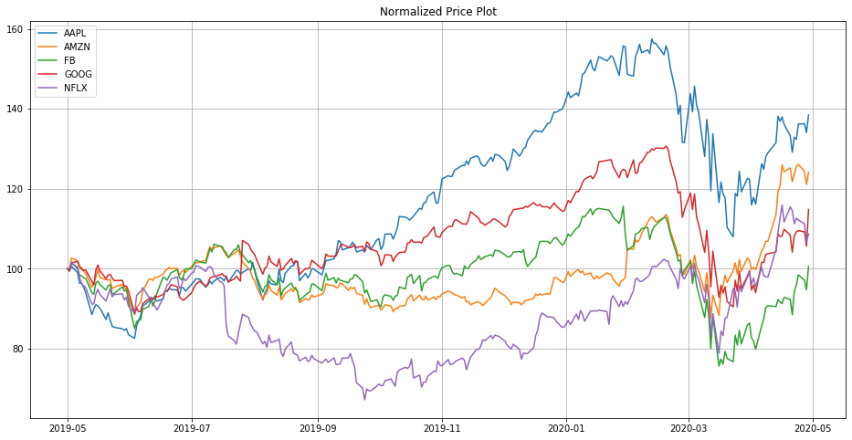

```python
# Visualize the data
fig = plt.figure(figsize=(16,8))
ax = plt.axes()

ax.set_title('Normalized Price Plot')
ax.plot(df[-252:]/df.iloc[-252] * 100)
ax.legend(df.columns, loc='upper left')
ax.grid(True)
```

```python
# Pass to Excel as picture
wb.sheets[2].pictures.add(ax.get_figure(),  name = 'Normalized Price Plot', update = True);
```

### Calculate Returns

```python
# Calculate returns
returns = df.pct_change().fillna(0)
returns.head()
```

| Date | AAPL | AMZN | FB | GOOG | NFLX |
| --- | --- | --- | --- | --- | --- |
| 2013-01-02 | 0.000000 | 0.000000 | 0.000000 | 0.000000 | 0.000000 |
| 2013-01-03 | -0.012623 | 0.004547 | -0.008214 | 0.000581 | 0.049777 |
| 2013-01-04 | -0.027855 | 0.002592 | 0.035650 | 0.019760 | -0.006315 |
| 2013-01-07 | -0.005882 | 0.035925 | 0.022949 | -0.004363 | 0.033549 |
| 2013-01-08 | 0.002692 | -0.007748 | -0.012237 | -0.001974 | -0.020565 |

#### Annualized Returns

In **MVP**, the average returns play an important role as they are used to approximate the expected returns.

```python
# Calculate annual returns
annual_returns = (returns.mean() * 252)
annual_returns
```

```
AAPL    0.234303
AMZN    0.349191
FB      0.321977
GOOG    0.211949
NFLX    0.574597
dtype: float64
```

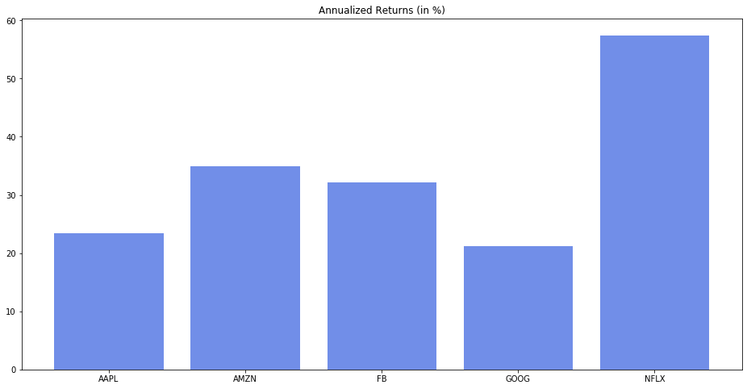

```python
# Visualize the data
fig = plt.figure()
ax =plt.axes()

ax.bar(annual_returns.index, annual_returns*100, color='royalblue', alpha=0.75)
ax.set_title('Annualized Returns (in %)');
```

### Calculate Volatility

```python
vols = returns.std()
vols
```

```
AAPL    0.017441
AMZN    0.019039
FB      0.021451
GOOG    0.016065
NFLX    0.029188
dtype: float64
```

#### Annualized Volatilities

```python
# Calculate annualized volatilities
annual_vols = vols*sqrt(252)
annual_vols
```

```
AAPL    0.276872
AMZN    0.302228
FB      0.340525
GOOG    0.255018
NFLX    0.463346
dtype: float64
```

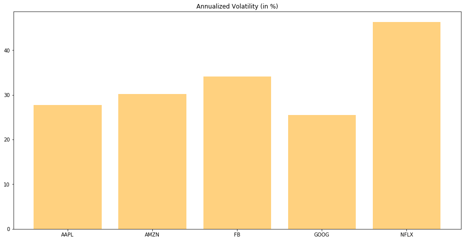

```python
# Visualize the data
fig = plt.figure()
ax = plt.axes()

ax.bar(annual_vols.index, annual_vols*100, color='orange', alpha=0.5)
ax.set_title('Annualized Volatility (in %)');
```

## Portfolio Statistics

Consider a portfolio fully invested in risky assets. Let $w$ and $\mu$ be the vector of weights and mean returns of *n* assets.

$$\ {w=}\left( \begin{array}{c} w_1 \\ w_2 \\ \vdots \\ w_n \\ \end{array}% \right); \ \mathbf{\mu=}\left( \begin{array}{ccc} \mu_1 \\ \mu_2 \\ \vdots \\ \mu_n \\ \end{array}% \right)$$

where the $\sum_{i=1}^{n}w_i=1$

**Expected Portfolio Return** is then the dot product of the expected returns and their weights.

$$\mu_\pi = w^T\cdot\mu$$

which is also equivalent to the $\Sigma_{i=1}^{n}w_i\mu_i$

**Expected Portfolio Variance** is then the multidot product of weights and the covariance matrix.

$$\sigma^2_\pi = w^T\cdot\Sigma\cdot w $$

where, ${\Sigma}$ is the covariance matrix

$${\Sigma=}\left( \begin{array}{ccc} \Sigma_{1,1} & \dots & \Sigma_{1,n} \\ \vdots & \ddots & \vdots \\ \Sigma_{n,1} & \dots & \Sigma_{n,n} \\ % \end{array}% \right)$$

### Equal Weighted Portfolio

Assume a portoflio composed of all five stocks with equal weighting. We will now calculate the portfolio statistics.

```python
wts = numofasset * [1./numofasset]
wts = array(wts)[:,newaxis]
wts
```

```
array([[0.2],
       [0.2],
       [0.2],
       [0.2],
       [0.2]])
```

```python
wts.shape
```

```
(5, 1)
```

### Portfolio Return

```python
array(returns.mean() * 252)[:,newaxis]
```

```
array([[0.23430293],
       [0.34919072],
       [0.32197723],
       [0.21194896],
       [0.57459721]])
```

```python
array(returns.mean() * 252)[:,newaxis].shape
```

```
(5, 1)
```

```python
# Portfolio returns
wts.T @ array(returns.mean() * 252)[:,newaxis]
```

```
array([[0.33840341]])
```

### Portfolio Volatility

```python
# Covariance matrix
returns.cov() * 252
```

|  | AAPL | AMZN | FB | GOOG | NFLX |
| --- | --- | --- | --- | --- | --- |
| AAPL | 0.076658 | 0.035316 | 0.040423 | 0.037194 | 0.031796 |
| AMZN | 0.035316 | 0.091342 | 0.051584 | 0.046479 | 0.061092 |
| FB | 0.040423 | 0.051584 | 0.115957 | 0.048473 | 0.054116 |
| GOOG | 0.037194 | 0.046479 | 0.048473 | 0.065034 | 0.049014 |
| NFLX | 0.031796 | 0.061092 | 0.054116 | 0.049014 | 0.214689 |

```python
# Portfolio variance
multi_dot([wts.T,returns.cov()*252,wts])
```

```
array([[0.05898624]])
```

```python
# Portfolio volatility
sqrt(multi_dot([wts.T,returns.cov()*252,wts]))
```

```
array([[0.24287083]])
```

### Portfolio statistics

Let's subsume key statistics into a function which can be used for optimization exercise.

```python
def portfolio_stats(weights):

    weights = array(weights)[:,newaxis]
    port_rets = weights.T @ array(returns.mean() * 252)[:,newaxis]
    port_vols = sqrt(multi_dot([weights.T, returns.cov() * 252, weights]))

    return np.array([port_rets, port_vols, port_rets/port_vols]).flatten()
```

```python
# import pyfolio as pf
# ewp = returns@wts
# ewp.columns =['ret']
# ewp.cumsum().iloc[-1]
# pf.create_simple_tear_sheet(ewp['ret'])
# plt.plot((1+ewp['ret']).cumprod())
```

## Portfolio Simulation

Now, we will implement a Monte Carlo simulation to generate random portfolio weights on a larger scale and calculate the expected portfolio return, variance and sharpe ratio for every simulated allocation. We will then identify the portfolio with a highest return for per unit of risk.

```python
w = random.random(numofasset)[:, newaxis]
w
```

```
array([[0.73071228],
       [0.29546453],
       [0.80955631],
       [0.51887521],
       [0.94671765]])
```

```python
w /= sum(w)
w
```

```
array([[0.22133903],
       [0.08949874],
       [0.24522156],
       [0.15717176],
       [0.28676891]])
```

```python
w.shape, sum(w)
```

```
((5, 1), 1.0)
```

```python
w.flatten()
```

```
array([0.22133903, 0.08949874, 0.24522156, 0.15717176, 0.28676891])
```

```python
# Initialize the lists
rets = []; vols = []; wts = []

# Simulate 5,000 portfolios
for i in range (5000):

    # Generate random weights
    weights = random.random(numofasset)[:, newaxis]

    # Set weights such that sum of weights equals 1
    weights /= sum(weights)

    # Portfolio statistics
    rets.append(weights.T @ array(returns.mean() * 252)[:, newaxis])
    vols.append(sqrt(multi_dot([weights.T, returns.cov()*252, weights])))
    wts.append(weights.flatten())

# Record values
port_rets = array(rets).flatten()
port_vols = array(vols).flatten()
port_wts = array(wts)
```

```python
port_rets
```

```
array([0.35707305, 0.29618286, 0.33362992, ..., 0.31770709, 0.42800177,
       0.279251  ])
```

```python
port_vols
```

```
array([0.25686246, 0.23370448, 0.24071775, ..., 0.24978323, 0.30708301,
       0.23486292])
```

```python
port_wts
```

```
array([[0.10229536, 0.25858244, 0.33512171, 0.10966283, 0.19433766],
       [0.15037849, 0.26709986, 0.1849133 , 0.33178864, 0.0658197 ],
       [0.20884835, 0.31201516, 0.19614571, 0.13792104, 0.14506974],
       ...,
       [0.24475179, 0.29517367, 0.40130422, 0.0156928 , 0.04307752],
       [0.09572436, 0.03079341, 0.37031346, 0.03731266, 0.46585611],
       [0.08408005, 0.22563284, 0.15040984, 0.49049904, 0.04937824]])
```

```python
port_rets.shape, port_vols.shape, port_wts.shape
```

```
((5000,), (5000,), (5000, 5))
```

```python
# Create a dataframe for analysis
mc_df = pd.DataFrame({'returns': port_rets,
                      'volatility': port_vols,
                      'sharpe_ratio': port_rets/port_vols,
                      'weights': list(port_wts)})
mc_df.head()
```

|  | returns | volatility | sharpe_ratio | weights |
| --- | --- | --- | --- | --- |
| 0 | 0.357073 | 0.256862 | 1.390133 | [0.1022953576940962, 0.258582440561544, 0.3351... |
| 1 | 0.296183 | 0.233704 | 1.267339 | [0.15037849053725097, 0.2670998625824491, 0.18... |
| 2 | 0.333630 | 0.240718 | 1.385980 | [0.20884834634356148, 0.3120151613921035, 0.19... |
| 3 | 0.321519 | 0.246906 | 1.302191 | [0.0722912415811056, 0.3639238703242672, 0.279... |
| 4 | 0.331910 | 0.239802 | 1.384100 | [0.29090539328744464, 0.14893053217562446, 0.1... |

### Summary Statistics

```python
# Summary Statistics
mc_df.describe().T
```

|  | count | mean | std | min | 25% | 50% | 75% | max |
| --- | --- | --- | --- | --- | --- | --- | --- | --- |
| returns | 5000.0 | 0.338653 | 0.036540 | 0.233262 | 0.312487 | 0.339100 | 0.362692 | 0.483160 |
| volatility | 5000.0 | 0.251080 | 0.016430 | 0.225572 | 0.239248 | 0.247734 | 0.259441 | 0.353876 |
| sharpe_ratio | 5000.0 | 1.346093 | 0.079102 | 1.019424 | 1.299260 | 1.368128 | 1.403803 | 1.467467 |

```python
# Write summary Statistics to Excel
wb.sheets[1]['A12'].value = mc_df.describe().T
```

### Maximum Sharpe Ratio Portfolio

```python
# Max sharpe ratio portfolio
msrp = mc_df.iloc[mc_df['sharpe_ratio'].idxmax()]
msrp
```

```
returns                                                  0.399836
volatility                                               0.272467
sharpe_ratio                                              1.46747
weights         [0.2330465373644255, 0.28529755077665614, 0.11...
Name: 1075, dtype: object
```

```python
# Max sharpe ratio portfolio weights
max_sharpe_port_wts = mc_df['weights'][mc_df['sharpe_ratio'].idxmax()]

# Allocation to achieve max sharpe ratio portfolio
dict(zip(symbols,np.around(max_sharpe_port_wts*100,2)))
```

```
{'AAPL': 23.3, 'AMZN': 28.53, 'FB': 11.8, 'GOOG': 0.37, 'NFLX': 36.0}
```

### Visulaize Simulated Portfolio

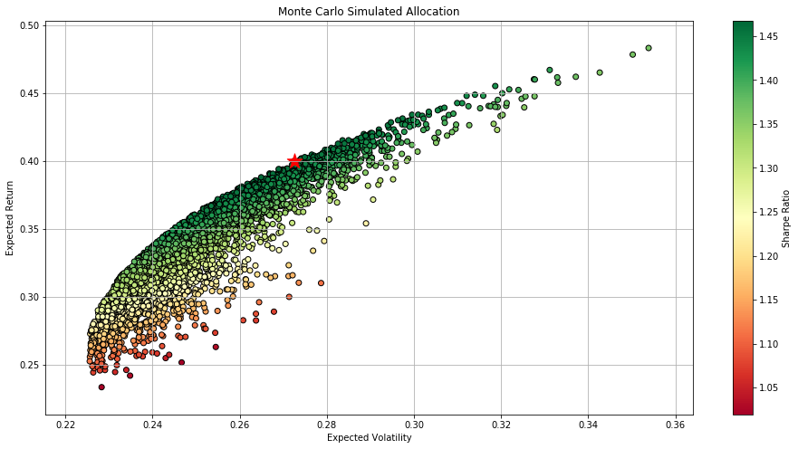

```python
# Visualize the simulated portfolio for risk and return
fig = plt.figure()
ax = plt.axes()

ax.set_title('Monte Carlo Simulated Allocation')

# Simulated portfolios
fig.colorbar(ax.scatter(port_vols, port_rets, c=port_rets / port_vols,
                        marker='o', cmap='RdYlGn', edgecolors='black'), label='Sharpe Ratio')

# Maximum sharpe ratio portfolio
ax.scatter(msrp['volatility'], msrp['returns'], c='red', marker='*', s = 300, label='Max Sharpe Ratio')

ax.set_xlabel('Expected Volatility')
ax.set_ylabel('Expected Return')
ax.grid(True)
```

```python
# Pass to Excel as picture
wb.sheets[3].pictures.add(ax.get_figure(),  name = 'Monte Carlo Simulated Allocation', update = True);
```

## Efficient Frontier

The Efficient Frontier is formed by a set of portfolios offering the highest expected portfolio return for a certain volatility or offering the lowest volatility for a certain level of expected returns.

**Return objective**:

$$\underset{w_1,w_2,\dots,w_n}{minimize} \space\space \sigma^2_{p}(w_1,w_2,\dots,w_n)$$

subject to,

$$E[R_p] = m$$

**Risk constraint**:

$$\underset{w_1,w_2,\dots,w_n}{maximize} \space\space E[R_p(w_1,w_2,\dots,w_n)]$$

subject to,

$$\sigma^2_{p}(w_1,w_2,\dots,w_n)=v^2$$

where, $\sum_{i=1}^{n}w_i=1$ for the above objectives.

We can use numerical optimization to achieve this objective. The goal of optimization is to find the optimal value of the objective function by adjusting the target variables operating withing some boundary conditions and constraints.

### Constrained Optimization

Construction of optimal portfolios is a constrained optimization problem where we specify some boundary conditions and constraints. The objective function here is a function returning maximum sharpe ratio, minimum variance (volatility) and the target variables are portfolio weights. We will use the *`minimize`* function from `scipy` optimization module to achieve our objective.

> ```
> sco.minimize(fun, x0, args=(), method=None, jac=None, hess=None, hessp=None,
>              bounds=None, constraints=(), tol=None, callback=None, options=None)
> ```

```python
# Import optimization module from scipy
import scipy.optimize as sco
```

#### Maximum sharpe ratio portfolio

```python
# Maximizing sharpe ratio
def min_sharpe_ratio(weights):
    return -portfolio_stats(weights)[2]
```

```python
cons = ({'type': 'eq', 'fun': lambda x: np.sum(x) - 1})
bnds = tuple((0, 1) for x in range(numofasset))
initial_wts = numofasset*[1./numofasset]
```

```python
# Optimizing for maximum sharpe ratio
opt_sharpe = sco.minimize(min_sharpe_ratio, initial_wts, method='SLSQP', bounds=bnds, constraints=cons)
```

```python
opt_sharpe
```

```
     fun: -1.47004724879622
     jac: array([-0.00015727,  0.00020869,  0.00023261,  0.134683  , -0.00020431])
 message: 'Optimization terminated successfully.'
    nfev: 36
     nit: 5
    njev: 5
  status: 0
 success: True
       x: array([2.00464434e-01, 3.22108090e-01, 1.41586603e-01, 2.24971951e-17,
       3.35840873e-01])
```

```python
# Portfolio weights
list(zip(symbols,np.around(opt_sharpe['x']*100,2)))
```

```
[('AAPL', 20.05),
 ('AMZN', 32.21),
 ('FB', 14.16),
 ('GOOG', 0.0),
 ('NFLX', 33.58)]
```

```python
# Portfolio stats
stats = ['Returns', 'Volatility', 'Sharpe Ratio']
list(zip(stats,np.around(portfolio_stats(opt_sharpe['x']),4)))
```

```
[('Returns', 0.398), ('Volatility', 0.2707), ('Sharpe Ratio', 1.47)]
```

#### Minumum variance portfolio

```python
# Minimize the variance
def min_variance(weights):
    return portfolio_stats(weights)[1]**2
```

```python
# Optimizing for minimum variance
opt_var = sco.minimize(min_variance, initial_wts, method='SLSQP', bounds=bnds, constraints=cons)
```

```python
opt_var
```

```
     fun: 0.05070031785695497
     jac: array([0.10156264, 0.10117618, 0.10132438, 0.10133453, 0.10169047])
 message: 'Optimization terminated successfully.'
    nfev: 63
     nit: 9
    njev: 9
  status: 0
 success: True
       x: array([0.35133027, 0.16067711, 0.06410734, 0.39000689, 0.03387839])
```

```python
# Portfolio weights
list(zip(symbols,np.around(opt_var['x']*100,2)))
```

```
[('AAPL', 35.13),
 ('AMZN', 16.07),
 ('FB', 6.41),
 ('GOOG', 39.0),
 ('NFLX', 3.39)]
```

```python
# Portfolio stats
list(zip(stats,np.around(portfolio_stats(opt_var['x']),4)))
```

```
[('Returns', 0.2612), ('Volatility', 0.2252), ('Sharpe Ratio', 1.16)]
```

#### Efficient Frontier portfolio

For efficient frontier portfolios, we fix a target return and derive for objective function.

```python
# Minimize the volatility
def min_volatility(weights):
    return portfolio_stats(weights)[1]
```

```python
targetrets = linspace(0.22,0.50,100)
tvols = []

for tr in targetrets:

    ef_cons = ({'type': 'eq', 'fun': lambda x: portfolio_stats(x)[0] - tr},
               {'type': 'eq', 'fun': lambda x: np.sum(x) - 1})

    opt_ef = sco.minimize(min_volatility, initial_wts, method='SLSQP', bounds=bnds, constraints=ef_cons)

    tvols.append(opt_ef['fun'])

targetvols = array(tvols)
```

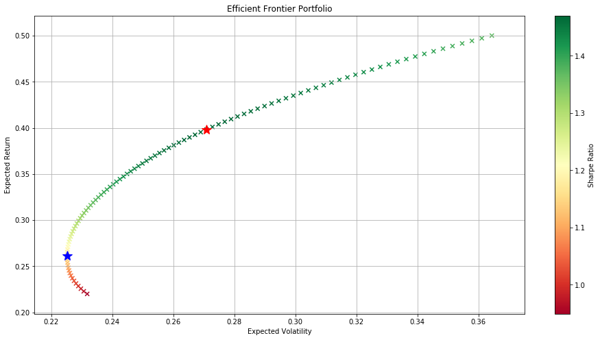

```python
# Visualize the simulated portfolio for risk and return
fig = plt.figure()
ax = plt.axes()

ax.set_title('Efficient Frontier Portfolio')

# Efficient Frontier
fig.colorbar(ax.scatter(targetvols, targetrets, c=targetrets / targetvols,
                        marker='x', cmap='RdYlGn', edgecolors='black'), label='Sharpe Ratio')

# Maximum Sharpe Portfolio
ax.plot(portfolio_stats(opt_sharpe['x'])[1], portfolio_stats(opt_sharpe['x'])[0], 'r*', markersize =15.0)

# Minimum Variance Portfolio
ax.plot(portfolio_stats(opt_var['x'])[1], portfolio_stats(opt_var['x'])[0], 'b*', markersize =15.0)

ax.set_xlabel('Expected Volatility')
ax.set_ylabel('Expected Return')
ax.grid(True)
```

# References

- Numpy linear algebra documentation https://numpy.org/doc/stable/reference/routines.linalg.html
- Scipy optimization function documentation https://docs.scipy.org/doc/scipy/reference/generated/scipy.optimize.minimize.html
- Xlwings documentation https://docs.xlwings.org/en/stable/index.html
- Yves Hilpisch (2018), Python For Finance: Analyze Big Financial Data